# Executive Summary: Motor Vehicle Insurance Loss Drivers

Take-home Exercise 1

Carina Peh

2026-05-24

## Contents

1. Study Objective and Data Scope
2. Portfolio Profile
3. Claim Occurrence and Severity
4. Profitability Patterns
5. Volatility Patterns
6. Portfolio Loss Ratio Trend
7. Key Loss Drivers: Profitability
8. Key Loss Drivers: Volatility
9. Risk Concentration: Severity vs Frequency
10. Executive Implications
11. Recommendations and Next Steps

## Study Objective and Data Scope

**Objective:** identify visual and statistical patterns that explain poor profitability and high volatility.

| Area | Summary |
| --- | --- |
| Dataset | Spanish motor vehicle insurance portfolio |
| Original data | 354,140 policy records, 47 variables |
| Analytical data | 352,338 records after missing value treatment |
| Period | 2022 to 2024 |
| Key outcomes | Loss ratio, claim frequency, has claim |

**Three derived measures drive the analysis:**

- **Loss ratio** = total incurred ÷ total premium — a ratio above 1 means the insurer paid out more than it collected
- **Claim frequency** = total claims ÷ total exposure — higher values indicate a more volatile portfolio
- **Has claim** = 1 if any claim was filed, 0 otherwise — separates claiming from non-claiming policies

## Portfolio Profile

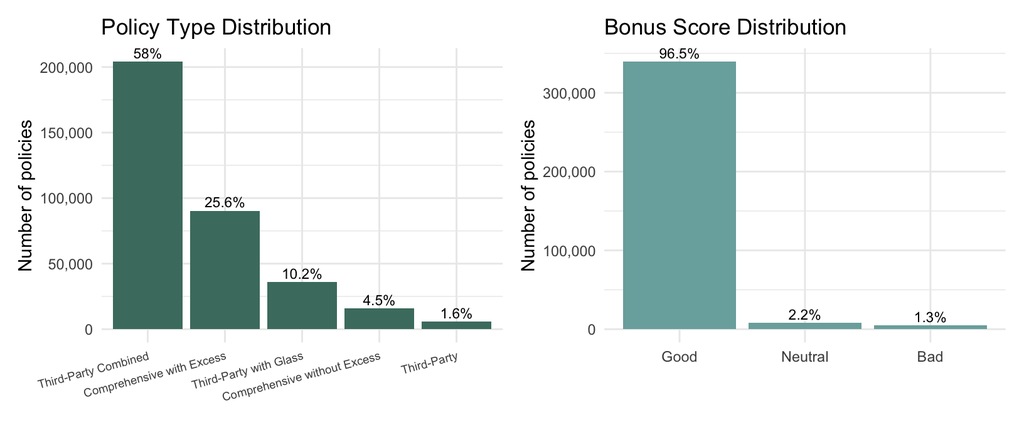

- **Third-Party Combined (58%)** dominates, performance issues here affect the whole portfolio
- **96.5%** of policyholders have a Good bonus score, portfolio appears low risk on the surface
- Aggregate stability can mask concentrated pockets of high-risk segments

## Claim Occurrence and Severity

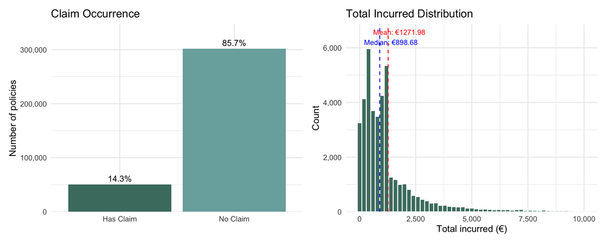

- **85.7%** of policies record no claims but the **14.3%** with claims drive all losses
- Most claims cost below €2,500 — but occasional large losses have an outsized impact
- The average claim cost (€1,271.98) is well above the typical claim (€898.68) a sign that severe claims are pulling the average up

## Profitability Patterns: Loss Ratio

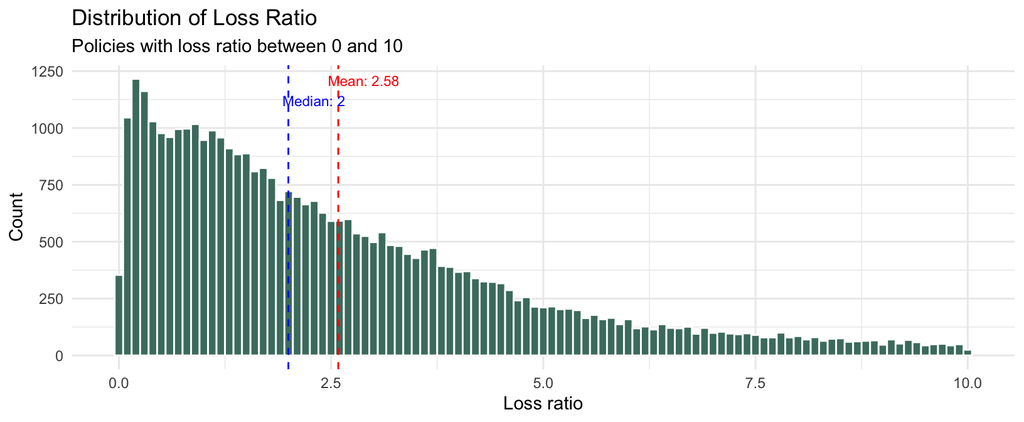